# MEDL_PS10_Soln

**Deep Learning for Mechanical Engineering**  
**Homework 10**  
**Due Wed., 11/29/2023, 4:00 PM**

Prof. Seungchul Lee  
http://iailab.kaist.ac.kr/  
Industrial AI Lab at KAIST

- For your handwritten solutions, please scan or take a picture of them. Alternatively, you can write them in markdown if you prefer.
- Only .ipynb files will be graded for your code.
  - Ensure that your NAME and student ID are included in your .ipynb files. ex) IljeokKim_20202467_HW08.ipynb
- Compress all the files into a single .zip file.
  - In the .zip file's name, include your NAME and student ID. ex) DogyeomPark_20202467_HW08.zip
  - Submit this .zip file on KLMS
- Do not submit a printed version of your code, as it will not be graded.

# Problem 1: LSTM with TensorFlow

- In this problem, you will make a LSTM model to predict the half of an MNIST image using the other half.
- You will split an MNIST image into 28 pieces.
- MNIST is 28 x 28 image. The model predicts a piece of 1 x 28 image.
- First, 14 x 28 image will be feeded into a model as time series, then the model predict the last 14 x 28 image, recursively.

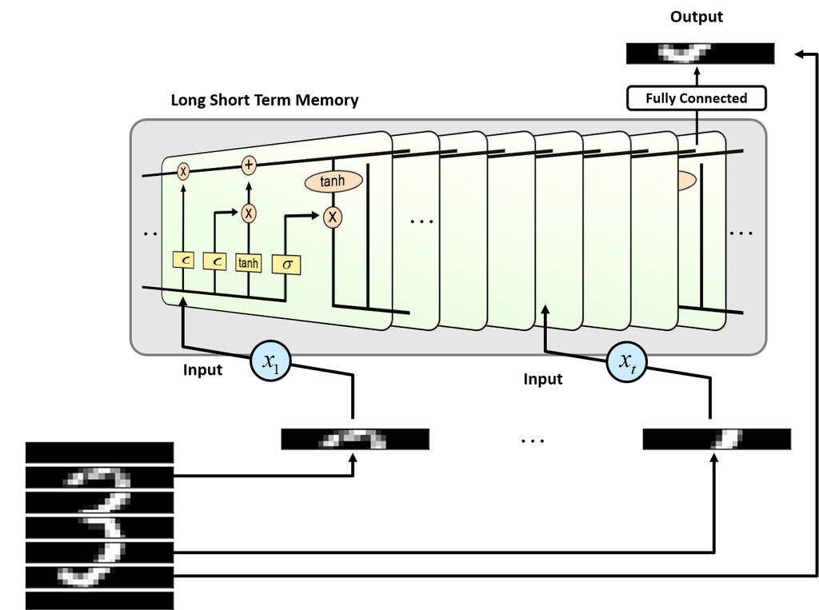

```python
import tensorflow as tf
import numpy as np
import matplotlib.pyplot as plt
```

(1) Load MNIST Data

- Download MNIST data from the tensorflow tutorial example

```python
(train_imgs, train_labels), (test_imgs, test_labels) = tf.keras.datasets.mnist.load_data()

train_imgs = train_imgs/255.0
test_imgs = test_imgs/255.0

print('train_x: ', train_imgs.shape)
print('test_x: ', test_imgs.shape)
```

```
Downloading data from https://storage.googleapis.com/tensorflow/tf-keras-datasets/mnist.npz
train_x:  (60000, 28, 28)
test_x:  (10000, 28, 28)
```

(2) Plot a ramdomly selected data with its label

```python
def batchmaker(x, y, n_batch):
    idx = np.random.randint(len(x), size = n_batch)
    return x[idx], y[idx]
```

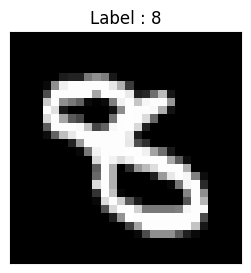

```python
train_x, train_y = batchmaker(train_imgs, train_labels, 1)
img = train_x[0].reshape(28, 28)

plt.figure(figsize = (5, 3))
plt.imshow(img,'gray')
plt.title("Label : {}".format(train_y[0]))
plt.xticks([])
plt.yticks([])
plt.show()
```

(3) Define LSTM Structure

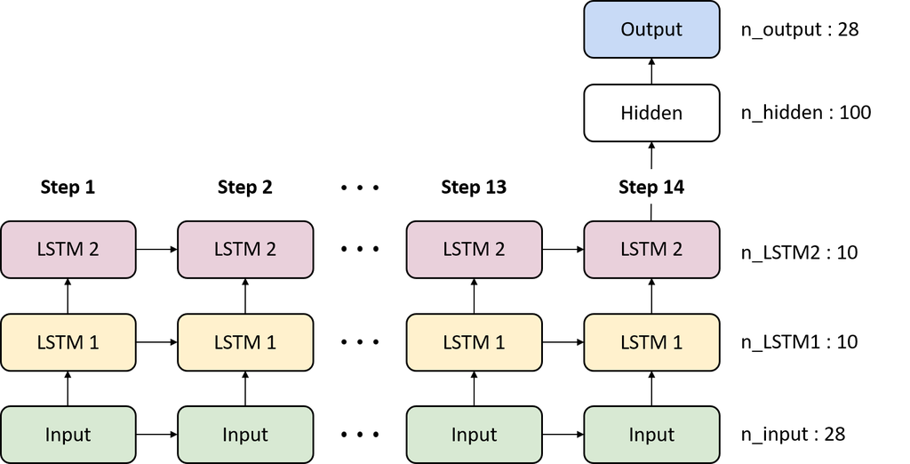

```python
n_step = 14
n_input = 28

## LSTM shape
n_lstm1 = 10
n_lstm2 = 10

## Fully connected
n_hidden = 100
n_output = 28
```

```python
lstm_network = tf.keras.models.Sequential([
    tf.keras.layers.Input(shape = (n_step, n_input)),
    tf.keras.layers.LSTM(n_lstm1, return_sequences = True),
    tf.keras.layers.LSTM(n_lstm2),
    tf.keras.layers.Dense(n_hidden, activation = 'relu'),
    tf.keras.layers.Dense(n_output),
])

lstm_network.summary()
```

```
Model: "sequential"
_________________________________________________________________
 Layer (type)                Output Shape              Param #
=================================================================
 lstm (LSTM)                 (None, 14, 10)            1560

 lstm_1 (LSTM)               (None, 10)                840

 dense (Dense)               (None, 100)               1100

 dense_1 (Dense)             (None, 28)                2828

=================================================================
Total params: 6,328
Trainable params: 6,328
Non-trainable params: 0
_________________________________________________________________
```

(4) Define Cost, Initializer and Optimizer Loss

- Regression: Squared loss

$$ \frac{1}{N} \sum_{i=1}^{N} (\hat{y}^{(i)} - y^{(i)})^2$$

Initializer

- Initialize all the empty variables

Optimizer

- AdamOptimizer: the most popular optimizer

```python
lstm_network.compile(optimizer = tf.keras.optimizers.Adam(learning_rate = 0.0005),
                     loss = 'mean_squared_error')
```

(5) Define optimization configuration and then optimize

```python
n_iter = 2000
n_prt = 200
batch_size = 10

for i in range(n_iter+1):
    train_x, train_y = batchmaker(train_imgs, train_labels, batch_size)

    for j in range(n_step):
        loss = lstm_network.train_on_batch(train_x[:, j:j+n_step, :], train_x[:, j+n_step, :])

    if i % n_prt == 0:
        train_loss = lstm_network.test_on_batch(train_x[:, 13:13+n_step, :], train_x[:, 13+n_step, :])
        print(train_loss)
```

```
0.0014543014112859964
0.0032421338837593794
0.008472677320241928
0.00035746616777032614
0.001835529925301671
0.010492042638361454
0.0002733171568252146
0.0002736546448431909
0.0003306472790427506
0.00020183045126032084
0.00015898968558758497
```

(6) Test or Evaluate

- Predict the MNIST image
- MNIST is 28 x 28 image. The model predicts a piece of 1 x 28 image.
- First, 14 x 28 image will be feeded into a model, then the model predict the last 14 x 28 image, recursively.

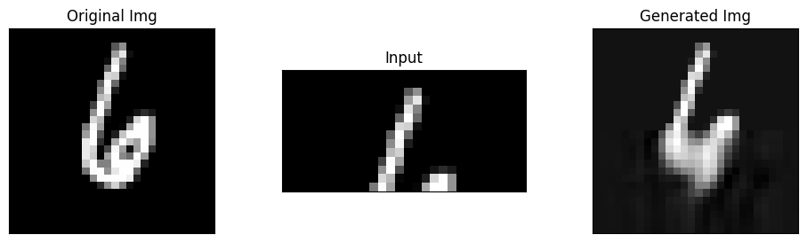

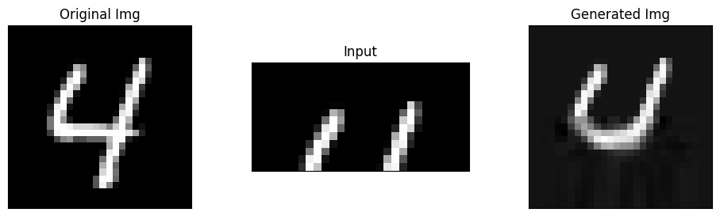

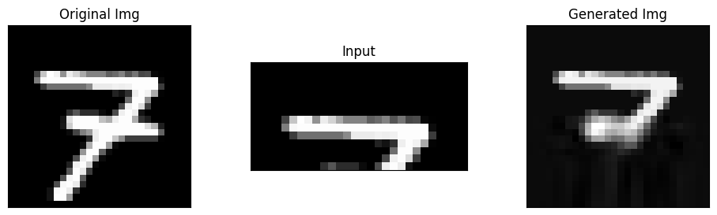

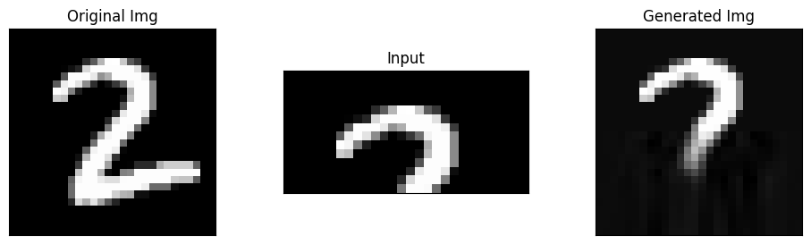

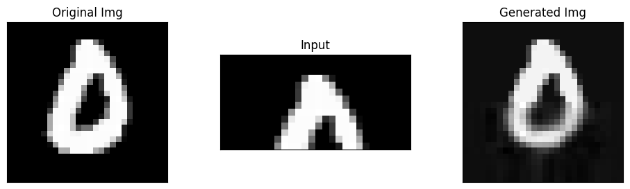

```python
test_x, test_y = batchmaker(test_imgs, test_labels, 5)

for idx in range(5):
    gen_img = []

    sample = test_x[idx, 0:14, :]
    input_img = sample.copy()

    feeding_img = test_x[idx, 0:0+n_step, :]

    for i in range(n_step):
        test_pred = lstm_network.predict(feeding_img.reshape(1, 14, 28), verbose = 0)
        feeding_img = np.delete(feeding_img, 0, 0)
        feeding_img = np.vstack([feeding_img, test_pred])
        gen_img.append(test_pred)

    for i in range(n_step):
        sample = np.vstack([sample, gen_img[i]])

    plt.figure(figsize = (12, 3))
    plt.subplot(1,3,1)
    plt.imshow(test_x[idx], 'gray')
    plt.title('Original Img')
    plt.xticks([])
    plt.yticks([])

    plt.subplot(1,3,2)
    plt.imshow(input_img, 'gray')
    plt.title('Input')
    plt.xticks([])
    plt.yticks([])

    plt.subplot(1,3,3)
    plt.imshow(sample, 'gray')
    plt.title('Generated Img')
    plt.xticks([])
    plt.yticks([])
    plt.show()
```

# Problem 2

- In this problem, we have bearing data with 3 classes (healthy, inner fault, outer fault).
- The objective is to classify the given data using deep learning models.

**Dataset Description**

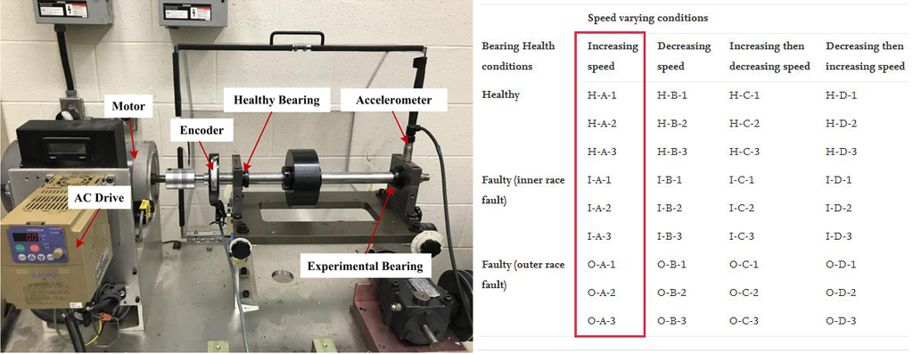

**Download & Load Data**

We already made the data ready for you. You can download the data in .npy format. Three files are prepared for a train set and three files for a test set.

- [Bearing_Healty_train.npy](https://drive.google.com/file/d/1WiIFy1QoIwY08W04XVYZLhuqIeWnYo2D/view?usp=sharing)
- [Bearing_InnerFault_train.npy](https://drive.google.com/file/d/1Mge0yUMlGivFRZpxh2DNjqIdYKg36-Ss/view?usp=sharing)
- [Bearing_OuterFault_train.npy](https://drive.google.com/file/d/19-8hdkCy8341yiQP5ZW6xLiIRNDceUko/view?usp=sharing)
- [Bearing_Healty_test.npy](https://drive.google.com/file/d/1N3Y4qS7kk_djZYuCOUdXjkepXsC9PFal/view?usp=sharing)
- [Bearing_InnerFault_test.npy](https://drive.google.com/file/d/1H9kktXrOlXnI5kazOb8ggqLjoRQDM48E/view?usp=sharing)
- [Bearing_OuterFault_test.npy](https://drive.google.com/file/d/1-D7gh0xKe26J1UDZcdmPS-oIQBdBbMyg/view?usp=sharing)

(1) Plot all data

```python
import tensorflow as tf
import numpy as np
import matplotlib.pyplot as plt
%matplotlib inline
```

```python
from google.colab import drive
drive.mount('/content/drive')
```

```python
Healthy_train = np.load('/content/drive/MyDrive/DL_Colab/DL_data/Bearing_Healthy_train.npy')
InnerFault_train = np.load('/content/drive/MyDrive/DL_Colab/DL_data/Bearing_InnerFault_train.npy')
OuterFault_train = np.load('/content/drive/MyDrive/DL_Colab/DL_data/Bearing_OuterFault_train.npy')

Healthy_test = np.load('/content/drive/MyDrive/DL_Colab/DL_data/Bearing_Healthy_test.npy')
InnerFault_test = np.load('/content/drive/MyDrive/DL_Colab/DL_data/Bearing_InnerFault_test.npy')
OuterFault_test = np.load('/content/drive/MyDrive/DL_Colab/DL_data/Bearing_OuterFault_test.npy')
```

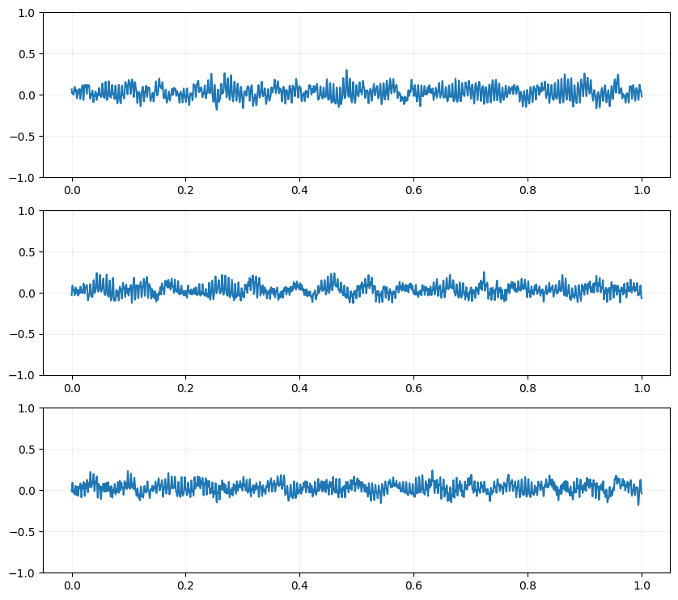

```python
idx = np.random.choice(Healthy_train.shape[0])
tindx = np.linspace(0, Healthy_train[idx].shape[0]/2000, Healthy_train[idx].shape[0])

plt.figure(figsize = (10, 9))

plt.subplot(3,1,1);  plt.plot(tindx, Healthy_train[idx]);  plt.ylim([-1, 1]);  plt.grid('on', alpha = 0.2)
plt.subplot(3,1,2);  plt.plot(tindx, InnerFault_train[idx]);  plt.ylim([-1, 1]);  plt.grid('on', alpha = 0.2)
plt.subplot(3,1,3);  plt.plot(tindx, OuterFault_train[idx]);  plt.ylim([-1, 1]);  plt.grid('on', alpha = 0.2)

plt.show()
```

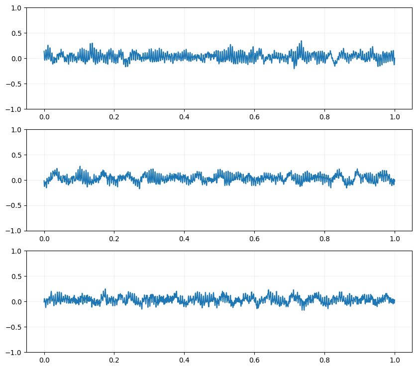

```python
idx = np.random.choice(Healthy_test.shape[0])

plt.figure(figsize = (10, 9))

plt.subplot(3,1,1);  plt.plot(tindx, Healthy_test[idx]);  plt.ylim([-1, 1]);  plt.grid('on', alpha = 0.2)
plt.subplot(3,1,2);  plt.plot(tindx, InnerFault_test[idx]);  plt.ylim([-1, 1]);  plt.grid('on', alpha = 0.2)
plt.subplot(3,1,3);  plt.plot(tindx, OuterFault_test[idx]);  plt.ylim([-1, 1]);  plt.grid('on', alpha = 0.2)

plt.show()
```

In the following subproblems, you will be introduced deep learning models which are used for time-series data classification. You are asked to build the model with the given architecture and evaluate the performance.

**Various deep learning models for time-series data classification**

In the deep learning field, there are plenty of models for time-series data classification. Compared to conventional machine learning algorithms, recent deep neural network models show much higher accuracy as you can see in the table below. In this problem, we will build the **CNN-LSTM model** whose elements are covered in this course.

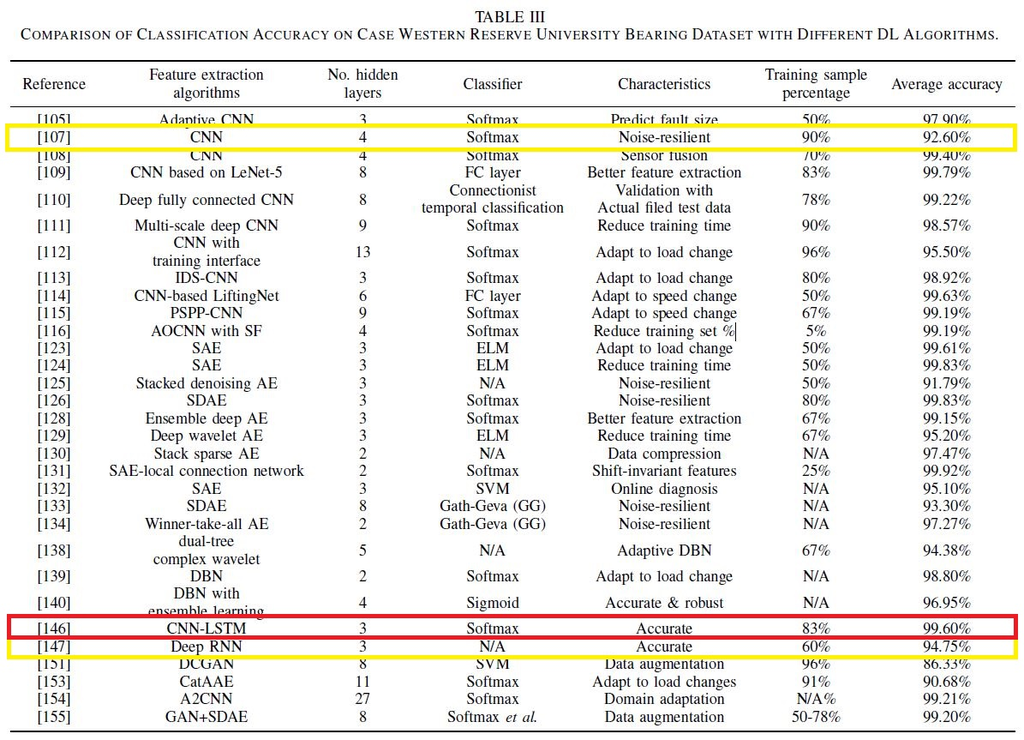

*"Deep Learning Algorithms for Bearing Fault Diagnostics – A Comprehensive Review", 2020, S Zhang et al.*

**Implementation of CNN-LSTM model**

The CNN-LSTM model is introduced in ["An Improved Bearing Fault Diagnosis Method using One-Dimensional CNN and LSTM."](https://www.sv-jme.eu/?ns_articles_pdf=/ns_articles/files/ojs/5249/public/5249-29704-1-PB.pdf&id=6130) The authors combined 1D CNN and LSTM succesfully and it shows high performance in terms of both computation time and accuracy. The following configuration shows a part of the structure of the model. The model takes the segmented data as an input. A data segment which has a length of 2,000 is randomly cropped from the original time-series data.

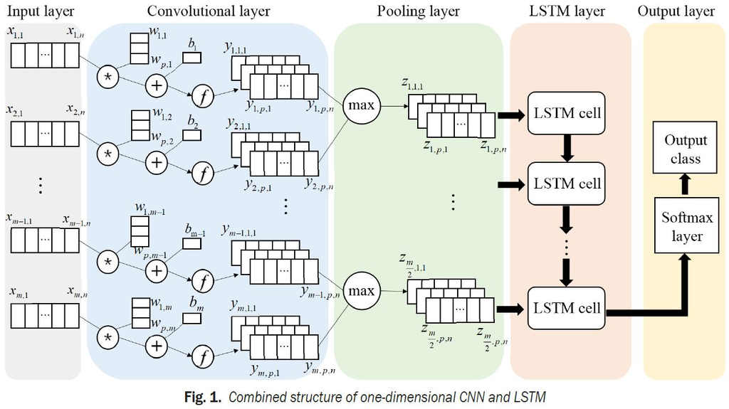

(2) Create trainset and testset

Create trainset and testset to feed the model you designed. Set the number of segments equals to 4,000 for trainset and 1,000 for testset (for each class).

```python
train_x = np.vstack((Healthy_train, InnerFault_train, OuterFault_train))

train_y = np.concatenate((np.zeros(Healthy_train.shape[0]),
                          np.ones(InnerFault_train.shape[0]),
                          2*np.ones(OuterFault_train.shape[0])))
```

```python
test_x = np.vstack((Healthy_test, InnerFault_test, OuterFault_test))
test_y = np.concatenate((np.zeros(Healthy_test.shape[0]),
                         np.ones(InnerFault_test.shape[0]),
                         2*np.ones(OuterFault_test.shape[0])))
```

(3) Build the model based on the above information and print the structure.

Build the model based on the above information and print the structure. You can freely assign the other parameters that are not described in the above configuration in order to achieve better performance. (You don't need to refer the original paper for those.) Please refer to the summary of the model structure.

You will use the 1D convolution layer for this problem. We have learned 2D convolution in class and 1D convolution is nothing but 2D convolution with a height as 1.

**Input_shape of data = (4000, 2000, 1)**

2000 $\rightarrow$ 20 $\times$ 100 $\rightarrow$ CNN layers $\rightarrow$ LSTM layer

```python
cnn_lstm_model = tf.keras.models.Sequential([
    tf.keras.layers.Reshape((20, 100),
                            input_shape = (2000,)),
    tf.keras.layers.Conv1D(filters = 32,
                           kernel_size = 64,
                           activation = 'relu',
                           padding = 'SAME'),
    tf.keras.layers.MaxPool1D(pool_size = 2, strides = 2),
    tf.keras.layers.LSTM(128),
    tf.keras.layers.Dense(3, activation = 'softmax')
])

cnn_lstm_model.compile(optimizer = tf.keras.optimizers.Adam(0.004),
                       loss = 'sparse_categorical_crossentropy',
                       metrics = ['accuracy'])

cnn_lstm_model.summary()
```

```
Model: "sequential_1"
_________________________________________________________________
 Layer (type)                Output Shape              Param #
=================================================================
 reshape (Reshape)           (None, 20, 100)           0

 conv1d (Conv1D)             (None, 20, 32)            204832

 max_pooling1d (MaxPooling1D  (None, 10, 32)           0
 )

 lstm_2 (LSTM)               (None, 128)               82432

 dense_2 (Dense)             (None, 3)                 387

=================================================================
Total params: 287,651
Trainable params: 287,651
Non-trainable params: 0
_________________________________________________________________
```

(4) Train the model and print the training procedure.

```python
cnn_lstm_train_record = cnn_lstm_model.fit(train_x, train_y, epochs = 10, batch_size = 50)
```

[output not shown]

(5) Evaluate the model in terms of accuracy of the testset.

```python
cnn_lstm_model.evaluate(test_x, test_y, batch_size = 50)
```

```
[0.006006747018545866, 0.9973333477973938]
```

(6) Build new model without 1DCNN, train it with the data you used for CNN+LSTM model, and test it with the test dataset used previously

```python
lstm_model = tf.keras.Sequential([
    tf.keras.layers.Reshape((20, 100), input_shape = (2000,)),
    tf.keras.layers.LSTM(128, return_sequences = True),
    tf.keras.layers.LSTM(32),
    tf.keras.layers.Dense(3, activation = 'softmax'),
])

lstm_model.compile(optimizer = tf.keras.optimizers.Adam(0.004),
                   loss = 'sparse_categorical_crossentropy',
                   metrics = ['accuracy'])

lstm_model.summary()
```

```
Model: "sequential_2"
_________________________________________________________________
 Layer (type)                Output Shape              Param #
=================================================================
 reshape_1 (Reshape)         (None, 20, 100)           0

 lstm_3 (LSTM)               (None, 20, 128)           117248

 lstm_4 (LSTM)               (None, 32)                20608

 dense_3 (Dense)             (None, 3)                 99

=================================================================
Total params: 137,955
Trainable params: 137,955
Non-trainable params: 0
_________________________________________________________________
```

```python
lstm_train_record = lstm_model.fit(train_x, train_y, epochs = 10, batch_size = 50)
```

```python
lstm_model.evaluate(test_x, test_y, batch_size = 50)
```

```
[0.005438053049147129, 0.9983333349227905]
```

(7) Compare loss and accuracy curves of two models (one with LSTM only and the other with CNN+LSTM)

Note that two models do not show big difference in terms of the accuarcy due to the simplicity of dataset.

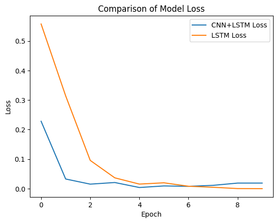

```python
plt.figure(figsize = (6, 4))

plt.plot(cnn_lstm_train_record.history['loss'], label = 'CNN+LSTM Loss')
plt.plot(lstm_train_record.history['loss'], label = 'LSTM Loss')
plt.title('Comparison of Model Loss')
plt.ylabel('Loss')
plt.xlabel('Epoch')
plt.legend(loc = 'upper right')
plt.show()
```

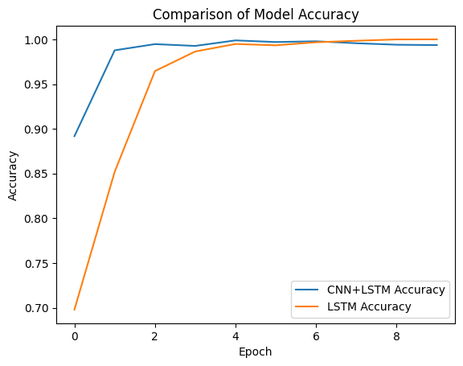

```python
plt.figure(figsize = (6, 4))

plt.plot(cnn_lstm_train_record.history['accuracy'], label = 'CNN+LSTM Accuracy')
plt.plot(lstm_train_record.history['accuracy'], label = 'LSTM Accuracy')
plt.title('Comparison of Model Accuracy')
plt.ylabel('Accuracy')
plt.xlabel('Epoch')
plt.legend(loc = 'lower right')
plt.show()
```